# Review 3

Here is your preflight checklist:

- I have one folder where this all resides. That folder is on Box.
- I have an analysis notebook that shows my code, explains my code and answers the question WHY I did what I did when did it. I showed my profesor my thinking, not just sentence fragments of what this code is.
- I can run my analysis notebook without error from the folder. I’ve either scraped the data straight from a website or the read_csv step points to my folder.
- If I have external data – meaning csvs, not scraped data – it’s in this folder and my analysis notebook points to it, not to ~/Desktop/ or something else.
- I have a public notebook that presents my visual story as a blog post for a sports website. I did not use the first person. My images appear in the notebook.
- I have all of my finished charts as images in the folder. I have not tried to embed PDFs in my public notebook because that will not work and I know that.
- Each of my charts has the required parts: A headline, chatter, credit line and source line.
- All of the text in my charts have a heirarchy – the headline stands out from the chatter, the source and credit lines are smaller, etc.
- Every word in my charts are spelled correctly.
- My charts do not use the default theme.
- My charts use color effectively and not excessively to illustrate the things I am hightlighting.
- My charts use labeling to point to things.
- My charts use the right form to show the data. I’ve used bar charts for categorical data, scatterplots when I’m showing a relationship between two numbers, etc.
- I’ve submitted a working Box link.

#### The biggest gotcha: Pathing

```r
library(tidyverse)
```

One new thing this time is that I’m going to run each one of your notebooks and they have to work or you lose points. Where most of you are going to struggle with this is with file pathing. Your `read_csv` step must connect to the csv file. So here’s the easiest way to do this:

1. Create a folder.
2. Put your analysis notebook in that folder.
3. Put your csv in that folder.
4. Your read_csv step now looks like this:

```r
logs <- read_csv("logs.csv")
```

The rest of your code should run without issue after that.

#### Other gotchas: Pathing to images

All semester long, you’ve become accustomed to everything that looks like code going into a code block like this:

```r
2+2
```

```
## [1] 4
```

But embedding images in your public notebook is not code. It’s markup. Markdown specifically. So it looks like this:

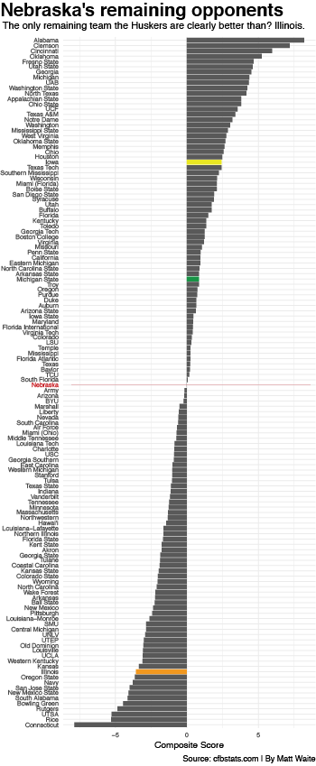

#### Required parts

Let’s whip up a chart quick:

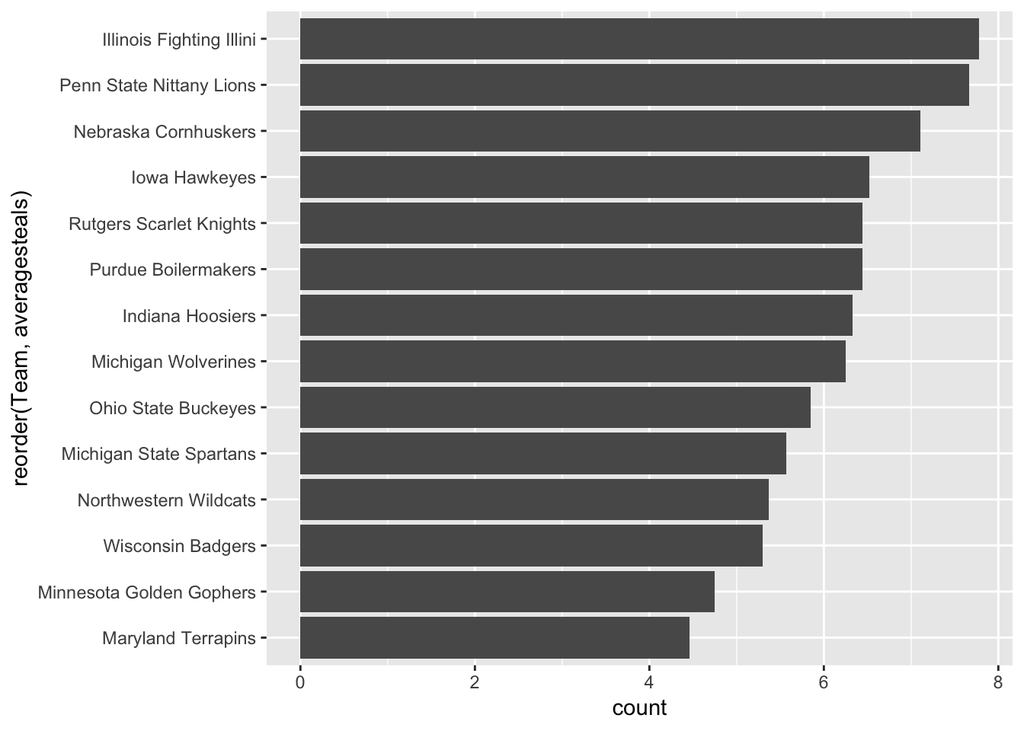

```r
logs %>% filter(Conference == "Big Ten") %>% group_by(Team) %>% summarize(averagesteals = mean(TeamSteals)) -> teamsteals

nu <- teamsteals %>% filter(Team == "Nebraska Cornhuskers")

ggplot() + geom_bar(data=teamsteals, aes(x=reorder(Team, averagesteals), weight=averagesteals)) + coord_flip()
```

First, let’s highlight Nebraska.

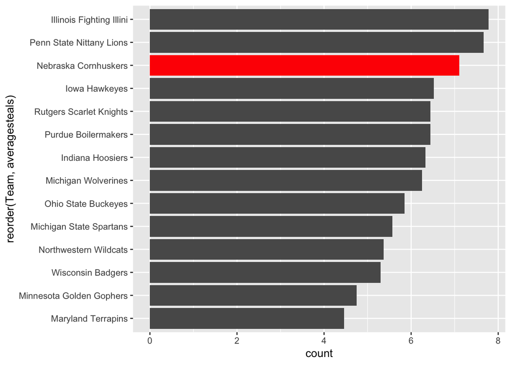

```r
ggplot() +
  geom_bar(data=teamsteals, aes(x=reorder(Team, averagesteals), weight=averagesteals)) +
  geom_bar(data=nu, aes(x=reorder(Team, averagesteals), weight=averagesteals), fill="red") +
  coord_flip()
```

No headline, no chatter, no credit or source line. Need to fix that.

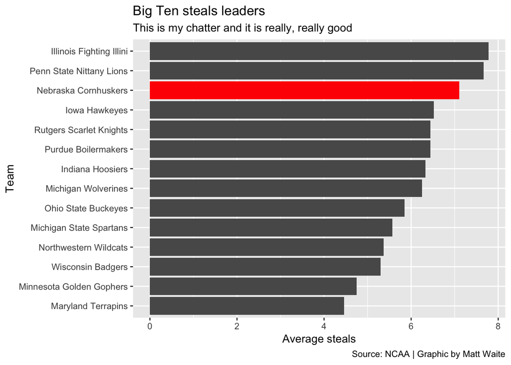

```r
ggplot() +
  geom_bar(data=teamsteals, aes(x=reorder(Team, averagesteals), weight=averagesteals)) +
  geom_bar(data=nu, aes(x=reorder(Team, averagesteals), weight=averagesteals), fill="red") +
  coord_flip() +
  labs(title="Big Ten steals leaders", subtitle="This is my chatter and it is really, really good", caption="Source: NCAA | Graphic by Matt Waite", x="Team", y="Average steals")
```

Now we need to get rid of the default theme.

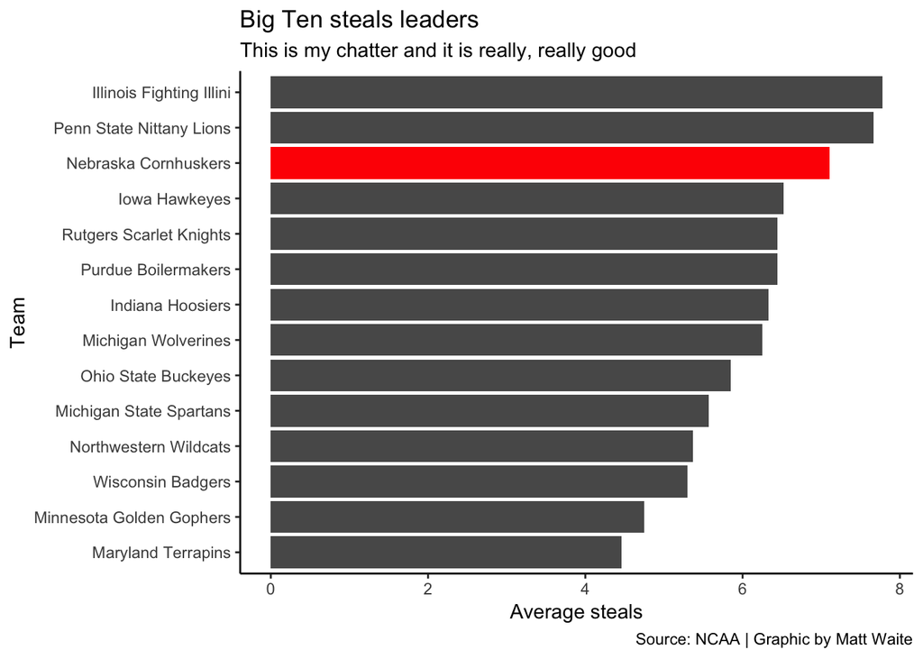

```r
ggplot() +
  geom_bar(data=teamsteals, aes(x=reorder(Team, averagesteals), weight=averagesteals)) +
  geom_bar(data=nu, aes(x=reorder(Team, averagesteals), weight=averagesteals), fill="red") +
  coord_flip() +
  labs(title="Big Ten steals leaders", subtitle="This is my chatter and it is really, really good", caption="Source: NCAA | Graphic by Matt Waite", x="Team", y="Average steals") +
  theme_classic()
```

Now we’re missing the text heirarchy.

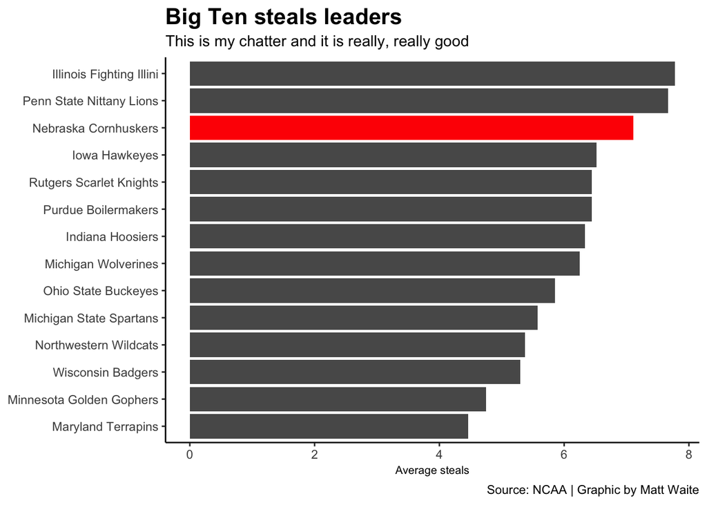

```r
ggplot() +
  geom_bar(data=teamsteals, aes(x=reorder(Team, averagesteals), weight=averagesteals)) +
  geom_bar(data=nu, aes(x=reorder(Team, averagesteals), weight=averagesteals), fill="red") +
  coord_flip() +
  labs(title="Big Ten steals leaders", subtitle="This is my chatter and it is really, really good", caption="Source: NCAA | Graphic by Matt Waite", x="Team", y="Average steals") +
  theme_classic() +
  theme(
    plot.title = element_text(size = 16, face = "bold"),
    axis.title = element_text(size = 8),
    axis.title.y = element_blank()
  )
```